# (R)Markdown

# Code chunks customisation

([Partially taken from here](https://bookdown.org/yihui/rmarkdown-cookbook/hide-one.html))

## Chunk naming (for reference)

```r
"You just put the name after the language declaration"
```

```
## [1] "You just put the name after the language declaration"
```

## Using variables as parameters

```r
typical_width <- 4
typical_height <- 4
```

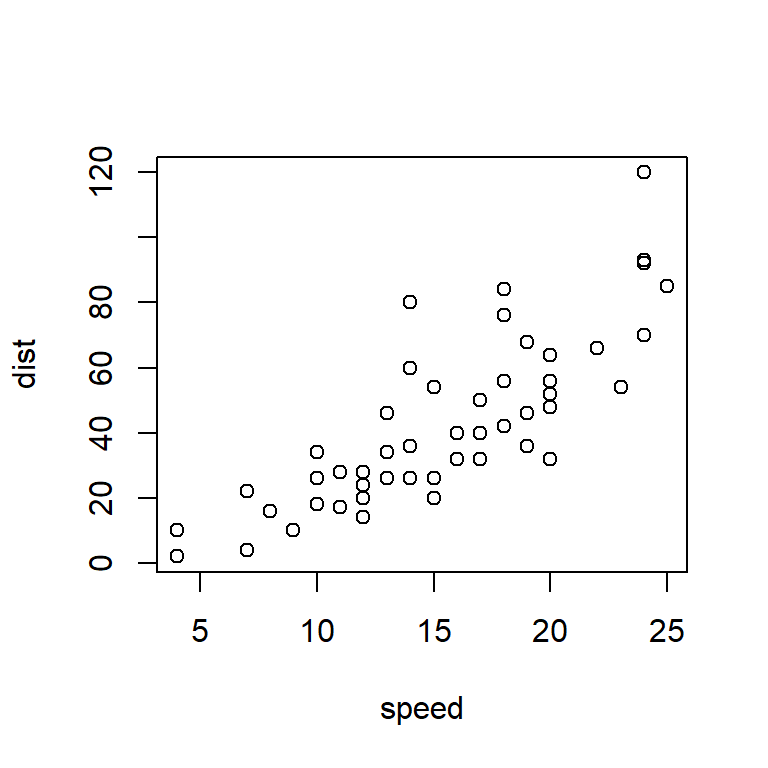

```r
plot(cars)
```

## Using variables within the text `'r variable'`

We have previously set a typical width to 4 and the typical height to 4.

## Conditional execution with `eval`

(`is.weekend` comes from the `chrono` package)

```r
cat("It's the weekend! :)")
```

```r
cat("It's not the weekend! :(")
```

```
## It's not the weekend! :(
```

## Handling errors

```r
543 + "clearly a text and not a number"
```

```
## Error in 543 + "clearly a text and not a number": argument nieliczbowy przekazany do operatora dwuargumentowego
```

By default RMarkdown stops after encountering an error. We can tell it to continue.

## Caching results that take long to compute

```r
Sys.sleep(10)
a <- 4
a
```

```
## [1] 4
```

The chunk gets reevaluated if anything changes within the chunk. **Make sure you know what you’re doing when caching**.

We can use `cache.extra =` to specify additional conditions for cache invalidation (i.e. to repeat the calculations), e.g.:

- file.mtime(‘filename’) # Modification time of the file changed
- tools::md5sum(‘filename’) # Content of the file changed
- getRversion() # R version changed
- etc.

Other stuff:

- `cache.comments` – if you don’t want to recalculate after changing a comment.
- `cache.lazy` – loading with lazyload() instead of load() (see [Lazy loading](https://en.wikipedia.org/wiki/Lazy_loading))
- `cache.path` – to specify where to save cached stuff
- `cache.vars` – cache specified objects
- `dependson` – reevaluate conditional on a change in a different chunk (or chunks)
- `autodep` – `knitr` will try to find the between-chunk dependencies on its own

## Keeping your report nice and clear

### Hide the source code with `echo=FALSE`

```
## [1] 2
```

### Hide messages (e.g. when loading stuff) with `message=FALSE`

```r
message("You will not see the message.")
```

### Hide warnings with `warning=FALSE`

```r
1:2 + 1:3
```

```
## [1] 2 4 4
```

### Hide plots with `fig.show='hide'`

```r
plot(cars)
```

### Hide everything from the chunk with `include=FALSE`

### Hide the results with `results='hide'`

```r
a*typical_height*typical_width
```

### Generate Markdown content with R code with `results='asis'`

```r
for (i in 1:10) {
  cat("- Item", i, "\n")
}
```

- Item 1
- Item 2
- Item 3
- Item 4
- Item 5
- Item 6
- Item 7
- Item 8
- Item 9
- Item 10

### Cluster the results with `results='hold'`

Standard:

```r
x <- 5
y <- 6
x + y
```

```
## [1] 11
```

```r
y - x
```

```
## [1] 1
```

```r
x * y
```

```
## [1] 30
```

With `results='hold'`:

```r
x <- 5
y <- 6
x + y
y - x
x * y
```

```
## [1] 11
## [1] 1
## [1] 30
```

### Compress the output with `collapse=TRUE`

Without

```r
1 + 1
```

```
## [1] 2
```

```r
1:10
```

```
##  [1]  1  2  3  4  5  6  7  8  9 10
```

With

```r
1 + 1
## [1] 2
1:10
##  [1]  1  2  3  4  5  6  7  8  9 10
```

# ASSIGNMENT 2 (for 30/31.03.2022)

Pick a TV show that had its premieres on TV and thus has some viewership numbers reported on Wikipedia. E.g. [Suits](https://en.wikipedia.org/wiki/List_of_Suits_episodes) (see table just above the References)

Then create a short report (you can copy the content from Wikipedia or other pages for this task) that contains, for example:

(do a commit after each step!)

1. A brief description of the show (use *italics* for names).
2. A photo with the logo or a shot from the show itself.
3. A summary of some basic statistics (e.g. on viewership or ratings).
4. A graph of the viewership over time.
5. A graph of the episode-to-episode (or season-to-season) changes in viewership.
6. A short description of the observed changes that includes inline references to numbers (e.g. the viewership decreased by `insert_calculated_number` between seasons 3 and 5).
7. Make sure your report looks nice -> this time we’re mostly interested in the output and not necessarily the codes used to achieve it.
8. `knitr` your report and save it in the relevant folder (RR_Mar_30_31) of your repo.
9. Commit the changes and push them to Github.

### Some other chunk options

E.g.:

- `highlight` – syntax coloring
- `tidy`– clean and format the code based on, e.g. `formatR` or `styler`, with specific options defined by `tidy.opts`

For chunks with figures, e.g.:

- `fig.align` – alignment
- `fig.ext` – image format
- `dev` – graphical device for the plot generation
- `dev.args`– arguments to be passed to device (e.g. for image customisation)
- `dpi` – DPI

You can, e.g., combine the above to produce images in DPI resolution and format appropriate for a publication.